# Reproducible Research_Course Project 1

Matias Barrenechea

March 11th 2016

## Assignement 1

Introduction

It is now possible to collect a large amount of data about personal movement using activity monitoring devices such as a Fitbit, Nike Fuelband, or Jawbone Up. These type of devices are part of the “quantified self” movement - a group of enthusiasts who take measurements about themselves regularly to improve their health, to find patterns in their behavior, or because they are tech geeks. But these data remain under-utilized both because the raw data are hard to obtain and there is a lack of statistical methods and software for processing and interpreting the data.

This assignment makes use of data from a personal activity monitoring device. This device collects data at 5 minute intervals through out the day. The data consists of two months of data from an anonymous individual collected during the months of October and November, 2012 and include the number of steps taken in 5 minute intervals each day.

The data for this assignment can be downloaded from the course web site:

Code for reading in the dataset and/or processing the data Histogram of the total number of steps taken each day Mean and median number of steps taken each day Time series plot of the average number of steps taken The 5-minute interval that, on average, contains the maximum number of steps Code to describe and show a strategy for imputing missing data Histogram of the total number of steps taken each day after missing values are imputed Panel plot comparing the average number of steps taken per 5-minute interval across weekdays and weekends All of the R code needed to reproduce the results (numbers, plots, etc.) in the report

## Load and transform data

```r
setwd("C:/Users/barrenecheam/Desktop/Reproducible REsearch")
library(data.table)
```

```r
library(ggplot2)
rData = read.csv('activity.csv', header = TRUE, sep = ",",
                  colClasses=c("numeric", "character", "numeric"))

rData$date = as.Date(rData$date, format = "%Y-%m-%d")
rData$interval = as.factor(rData$interval)
```

## What is mean total number of steps taken per day?

```r
stepsPerDay = aggregate(steps ~ date, rData, sum)
colnames(stepsPerDay) = c("date","steps")

stepsMean   = mean(stepsPerDay$steps, na.rm=TRUE)
stepsMean
```

```
## [1] 10766.19
```

```r
stepsMedian = median(stepsPerDay$steps, na.rm=TRUE)
stepsMedian
```

```
## [1] 10765
```

## What is the average daily activity pattern?

```r
stepsPerInterval = aggregate(rData$steps,
                                by = list(interval = rData$interval),
                                FUN=mean, na.rm=TRUE)

stepsPerInterval$interval =
  as.integer(levels(stepsPerInterval$interval)[stepsPerInterval$interval])
colnames(stepsPerInterval) = c("interval", "steps")

maxInterval = stepsPerInterval[which.max(stepsPerInterval$steps),]
maxInterval
```

```
##     interval    steps
## 104      835 206.1698
```

## Imputing missing values

```r
missingVals = sum(is.na(rData$steps))

naFill = function(data, pervalue) {
  na_index = which(is.na(data$steps))
  na_replace = unlist(lapply(na_index, FUN=function(idx){
    interval = data[idx,]$interval
    pervalue[pervalue$interval == interval,]$steps
  }))
  fill_steps = data$steps
fill_steps[na_index] = na_replace
  fill_steps
}

rDataFill = data.frame(
  steps = naFill(rData, stepsPerInterval),
  date = rData$date,
  interval = rData$interval)

sum(is.na(rDataFill$steps))
```

```
## [1] 0
```

```r
fillStepsPerDay = aggregate(steps ~ date, rDataFill, sum)
colnames(fillStepsPerDay) = c("date","steps")

stepsMeanFill   = mean(fillStepsPerDay$steps, na.rm=TRUE)
stepsMedianFill = median(fillStepsPerDay$steps, na.rm=TRUE)
```

## Are there differences in activity patterns between weekdays and weekends?

```r
weekdaysSteps = function(data) {
weekdaysSteps = aggregate(data$steps, by=list(interval = data$interval),
FUN=mean, na.rm=T)
# convert to integers for plotting
weekdaysSteps$interval =
as.integer(levels(weekdaysSteps$interval)[weekdaysSteps$interval])
colnames(weekdaysSteps) = c("interval", "steps")
weekdaysSteps
}

dataByWeekdays = function(data) {
data$weekday =
as.factor(weekdays(data$date)) # weekdays
weekendData = subset(data, weekday %in% c("sábado","domingo"))
weekdayData = subset(data, !weekday %in% c("sábado","domingo"))

weekendSteps = weekdaysSteps(weekendData)
weekdaySteps = weekdaysSteps(weekdayData)

weekendSteps$dayofweek = rep("weekend", nrow(weekendSteps))
weekdaySteps$dayofweek = rep("weekday", nrow(weekdaySteps))

dataByWeekdays = rbind(weekendSteps, weekdaySteps)
dataByWeekdays$dayofweek = as.factor(dataByWeekdays$dayofweek)
dataByWeekdays
}

data_weekdays = dataByWeekdays(rDataFill)
```

## Plots

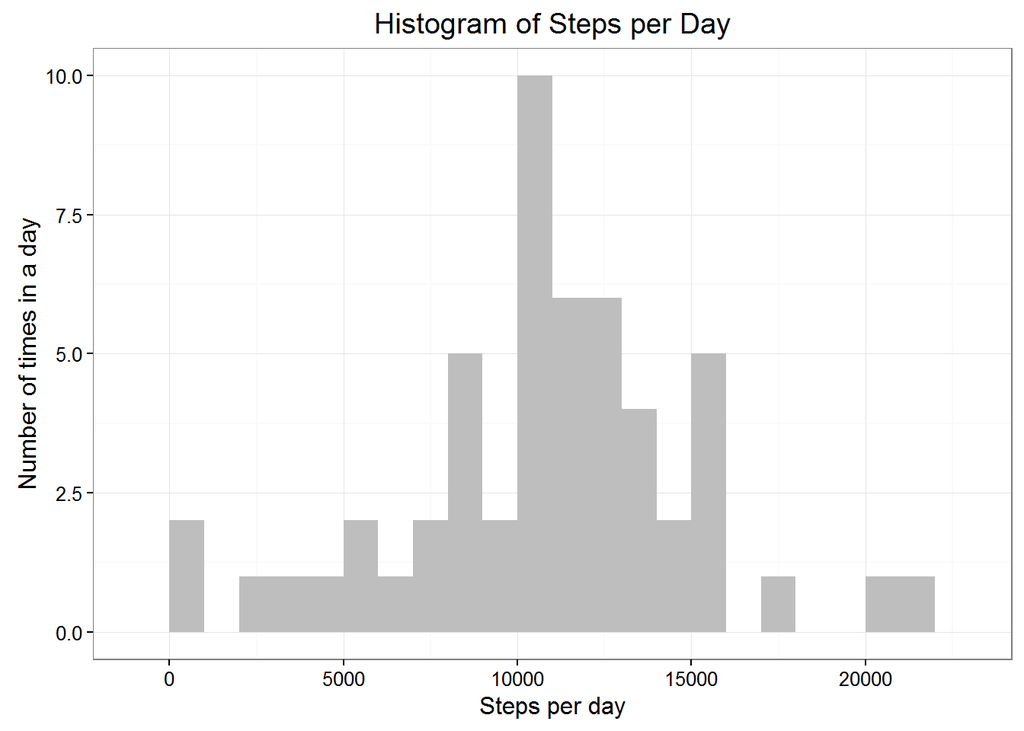

```r
ggplot(stepsPerDay, aes(x = steps)) +
       geom_histogram(fill = "gray", binwidth = 1000) +
        labs(title="Histogram of Steps per Day",
             x = "Steps per day", y = "Number of times in a day") + theme_bw()
```

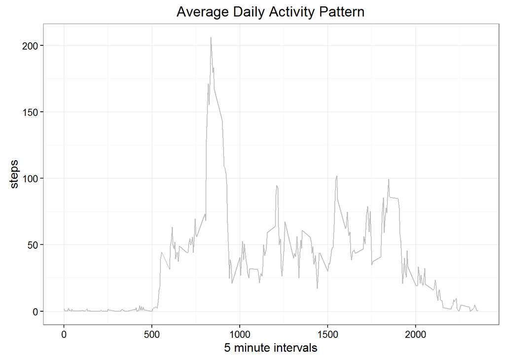

```r
ggplot(stepsPerInterval, aes(x=interval, y=steps)) +
  geom_line(color="gray") +
  labs(title="Average Daily Activity Pattern", x="5 minute intervals", y="steps") +
  theme_bw()
```

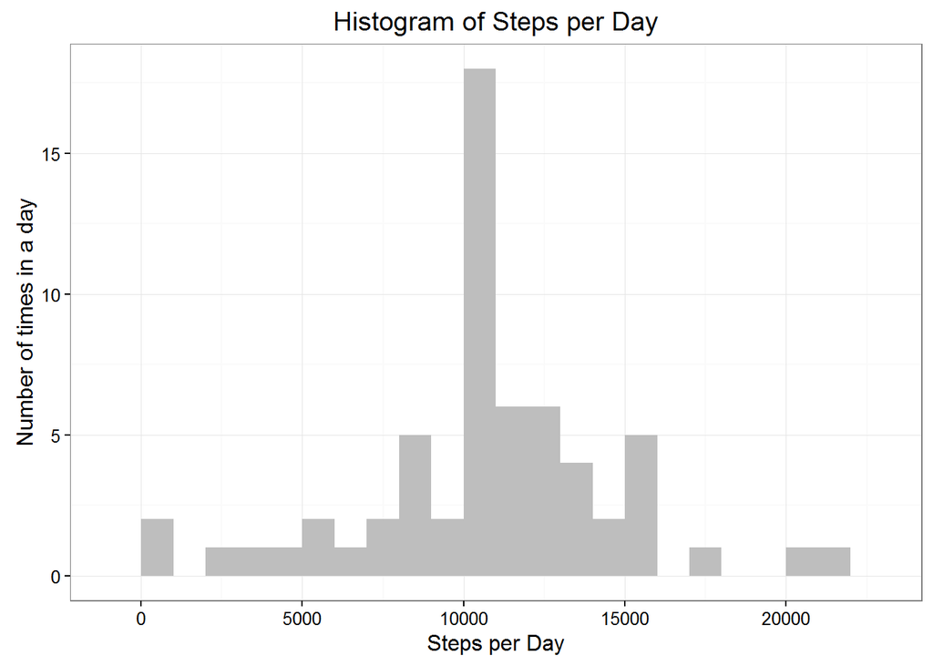

```r
ggplot(fillStepsPerDay, aes(x = steps)) +
  geom_histogram(fill = "gray", binwidth = 1000) +
  labs(title="Histogram of Steps per Day",
       x = "Steps per Day", y = "Number of times in a day") + theme_bw()
```

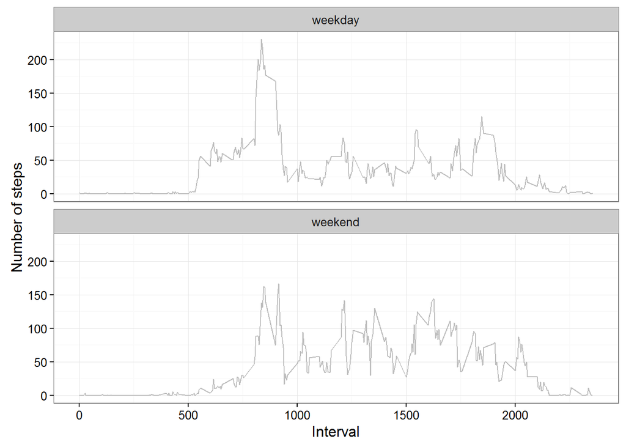

```r
ggplot(data_weekdays, aes(x=interval, y=steps)) +
geom_line(color="gray") +
facet_wrap(~ dayofweek, nrow=2, ncol=1) +
labs(x="Interval", y="Number of steps") +
theme_bw()
```